# Fish Prices

Ernesto Carrella

April 21, 2016

## Fish Prices

In our model agents react quite strongly to changes in prices. Most of these examples had exogenous and fixed prices. In a few cases however the price was endogenous and a function of how much fishers were catching. This endogeneity is crucial for results like [effort modulation](http://carrknight.github.io/poseidon/effort.html) and how ITQ can [solve race to fish](http://carrknight.github.io/poseidon/race.html). These results are therefore contingent on the existence of a downward sloping demand curve.

For those results to apply in our California model we need a demand curve. Barbara pointed me to some landings and prices data. For the pacific we have monthly observations for 3 of the species we are interested in: Sablefish, Dover Sole and Shortspine. Longspine isn’t recorded and Yelloweye is caught too infrequently.  
If we just look at the time series of prices we see something like this:

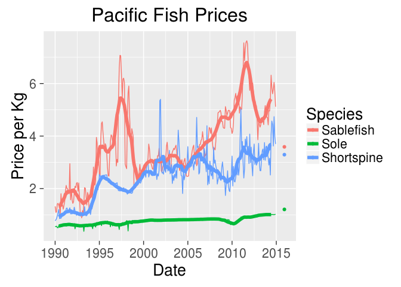

The bolded lines are 12 month moving averages (2-sided). The dots are the 2015 ex-vessel prices at Morro Bay. The prices vary both month to month and year to year. Unfortunately it doesn’t look like there is a nice simple linear relationship between quantity fished out and price fetches (except maybe for Dover Sole):

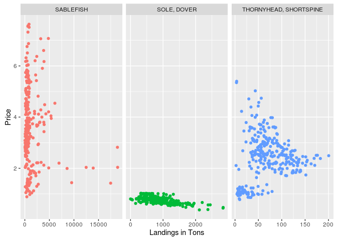

The main obvious issue is however auto-correlation. Prices last month are very similar to prices this year. Since we aren’t interested in a full treatment of the demand we are going to choose fit the data to whatever function predicts better (in terms of cross-validation errors) among the following choices:
$$\begin{align}
p^i_t &= \alpha + \beta q^i_t \\
p^i_t &= \alpha + \beta \log q^i_t \\
p^i_t &= \alpha + \sum \beta_j q^j_t \\
p^i_t &= \alpha + \sum \beta_j \log q^j_t \\
p^i_t &= \alpha + \gamma p^i_{t-1} + \beta q^i_t \\
p^i_t &= \alpha + \gamma p^i_{t-1} + \beta \log q^i_t \\
p^i_t &= \alpha + \gamma p^i_{t-1} + \sum \beta_j q^j_t \\
p^i_t &= \alpha + \gamma p^i_{t-1} + \sum \beta_j \log q^j_t \\
\end{align}$$
Where $i$ is the species index. Basically we need to choose whether to regress the price against quantity of the same species or all the species, we need to choose whether to regress linearly or log-linearly and we need to choose whether to add last month price as a predictor for the current one or not.

Turns out that for all species the only choice that really lowers cross-validation error is to include past price as predictor. If we use the 5th equation as formula and predictor we get:

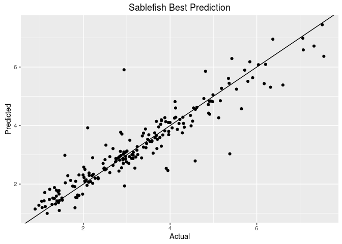

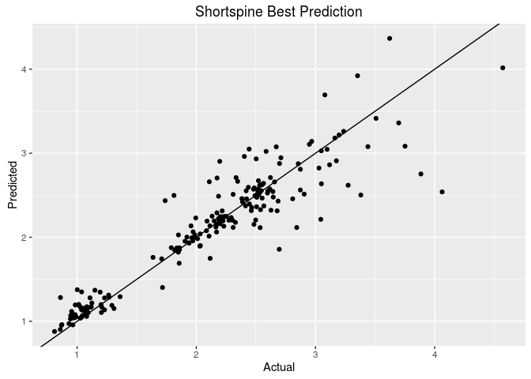

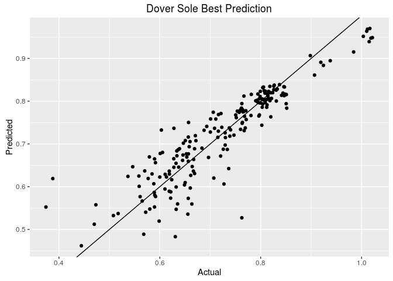

Here’s the kicker however: both sablefish and shortspine seem to proceed by random-walk (the lag coefficient being 1) and for shortspine in particular the quantity supplied having no effect at all.

|  | Estimate | Std. Error | t value | Pr(>\|t\|) |
| --- | --- | --- | --- | --- |
| **lagprice** | 0.9552 | 0.0257 | 37.17 | 1.968e-90 |
| **SABLEFISH.quantity** | 3.014e-05 | 1.318e-05 | 2.287 | 0.02329 |
| **(Intercept)** | 0.1333 | 0.09626 | 1.384 | 0.1678 |

Fitting linear model: SABLEFISH.price ~ lagprice + SABLEFISH.quantity

| Observations | Residual Std. Error | $R^2$ | Adjusted $R^2$ |
| --- | --- | --- | --- |
| 198 | 0.5188 | 0.8767 | 0.8754 |

This is the shortspine regression :

|  | Estimate | Std. Error | t value | Pr(>\|t\|) |
| --- | --- | --- | --- | --- |
| **lagprice** | 0.9594 | 0.03005 | 31.92 | 3.742e-79 |
| **`THORNYHEAD, SHORTSPINE.quantity`** | -0.0003785 | 0.0005144 | -0.7359 | 0.4627 |
| **(Intercept)** | 0.1381 | 0.06199 | 2.228 | 0.02703 |

Fitting linear model: `THORNYHEAD, SHORTSPINE.price` ~ lagprice + `THORNYHEAD, SHORTSPINE.quantity`

| Observations | Residual Std. Error | $R^2$ | Adjusted $R^2$ |
| --- | --- | --- | --- |
| 197 | 0.287 | 0.8591 | 0.8577 |

The only one that looks usable is Dover-Sole:

|  | Estimate | Std. Error | t value | Pr(>\|t\|) |
| --- | --- | --- | --- | --- |
| **lagprice** | 0.6423 | 0.0369 | 17.4 | 1.471e-41 |
| **`SOLE, DOVER.quantity`** | -9.188e-05 | 8.957e-06 | -10.26 | 5.082e-20 |
| **(Intercept)** | 0.3478 | 0.03224 | 10.79 | 1.429e-21 |

Fitting linear model: `SOLE, DOVER.price` ~ lagprice + `SOLE, DOVER.quantity`

| Observations | Residual Std. Error | $R^2$ | Adjusted $R^2$ |
| --- | --- | --- | --- |
| 198 | 0.05173 | 0.8113 | 0.8094 |